## 7. Vorlesung: Distanz-Maße und Clustering

### GTEx

Das “Gene-Tissue expression”=Projekt (GTEx) ist eine große internationale Zusammenarbeit, um

- Proben vieler verschiedener menschlicher Gewebe post mortem von verschiedenen Spendern zu sammeln
- die Spender zu genotypisieren (durch Sequenzierung der gesamten oder der exonischen DNA)
- die mRNA aller Gewebeproben zu sequenzieren

um zu untersuchen

- wie sich die Genexpression zwischen verschiedenen Geweben unterscheidet
- wie sich die Genexpression zwischen verschiedenen Menschen unterscheidet
- wie der Genotyp die Genexpression (ein Phänotyp) bestimmt

Heute verwenden wir einige GTEx-Daten als Beispiele.

```r
library( tidyverse )
```

Ich habe Beispieldaten vorbereitet, die wir hier laden:

```r
load( "L7_gtex_example_data.rds" )
```

(Diese “rds”-Datei enthält drei Variablen: `countMatrix`, `sampleTable` und `tissueMedians`. Die letzte brauchen wir erst später.)

Hier die RNA-Seq-Counts von einigen der GTEx-Proben:

```r
countMatrix[ 1:10, 1:10 ]
```

```
##              5EGHI 5GZZP 5EQKS 59HJ5 5LZU2 5EQ5I 5K7UU 5IJBT 9WG72 5KM2Y
## DDX11L1          0     0     0     0     0     0     0     0     1     0
## WASH7P         109   112   108    98   119    91   131    36   115   109
## MIR6859-1        0     0     0     0     0     0     0     0     0     0
## MIR1302-2HG      0     1     0     0     0     0     0     0     0     0
## FAM138A          0     0     0     0     0     2     0     0     0     0
## OR4G4P           1     0     1     0     1     1     0     0     1     0
## OR4G11P          1     1     0     1     2     2     1     2     1     1
## OR4F5            2     0     4     3     0     1     0     1     1     1
## RP11-34P13.7     2     0     0     0     2     0     0     0     0     0
## CICP27           1     3     0     0     0     0     2     4     4     8
```

Die Count-Matrix von GTEx enthält eigentlich 22.950 Sample. Diese große Matrix kann man auf der GTEx-Webseite (https://gtexportal.org/) als Datei `GTEx_Analysis_2017-06-05_v8_RNASeQCv1.1.9_gene_reads.gct.gz` herunterladen. Für unser Beispiel have ich daraus nur 44 ausgewählt. Daher hat unsere Matrix nur 44 Spalten.

```r
dim(countMatrix)
```

```
## [1] 56200    44
```

und die zugehörige Proben-Tabelle (generiert aus der großen Tabelle `GTEx_Analysis_v8_Annotations_SampleAttributesDS.txt`)

```r
sampleTable %>% head
```

```
## # A tibble: 6 x 6
##   SAMPID              SMTS       SMTSD         donor_id tissue_site_id sample_id
##   <chr>               <chr>      <chr>         <chr>    <chr>          <chr>
## 1 GTEX-1117F-0426-SM… Muscle     Muscle - Ske… 1117F    0426           5EGHI
## 2 GTEX-11DXX-0826-SM… Blood Ves… Artery - Cor… 11DXX    0826           5GZZP
## 3 GTEX-11UD2-0826-SM… Blood Ves… Artery - Aor… 11UD2    0826           5EQKS
## 4 GTEX-1212Z-2826-SM… Blood Ves… Artery - Tib… 1212Z    2826           59HJ5
## 5 GTEX-13111-2126-SM… Blood Ves… Artery - Tib… 13111    2126           5LZU2
## 6 GTEX-1313W-1026-SM… Blood Ves… Artery - Aor… 1313W    1026           5EQ5I
```

```r
sampleTable %>% group_by( SMTSD ) %>% count
```

```
## # A tibble: 4 x 2
## # Groups:   SMTSD [4]
##   SMTSD                 n
##   <chr>             <int>
## 1 Artery - Aorta       15
## 2 Artery - Coronary    15
## 3 Artery - Tibial      13
## 4 Muscle - Skeletal     1
```

Als erstes vergleichen wir die RNA-Seq-Daten von drei Proben:

- links: Proben von Herzkranzgefäße von zwei verschiedenen Spendern
- rechts: die erste Herzkrankgefäß-Probe und eine Probe eines Skelettmuskels eines dritten Spenders

Jeder Punkt ist ein Gen, seine Koordianten sind die Anzahl der Sequenzier-Reads, die in den beiden Probem dem Gen zugeordnet wurden

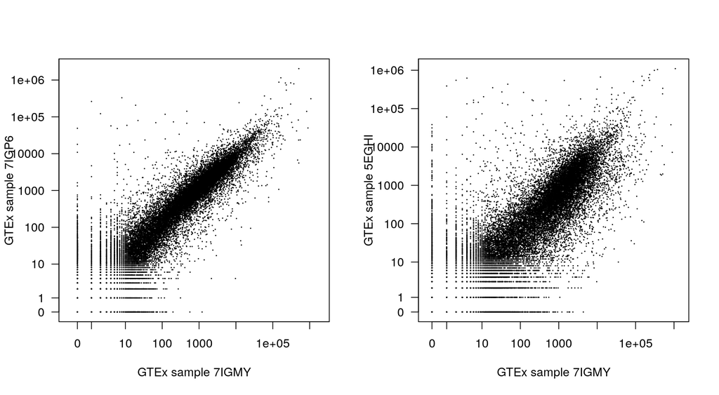

Hier ist es schwer, zu sehen, wie viele Punkte direkt übereinander geplottet wurden (“overplotting”). Daher derselbe Plot nochmal, mit Transparenz (jeder Punkt deckt nur zu 20% [“20% opacity”])

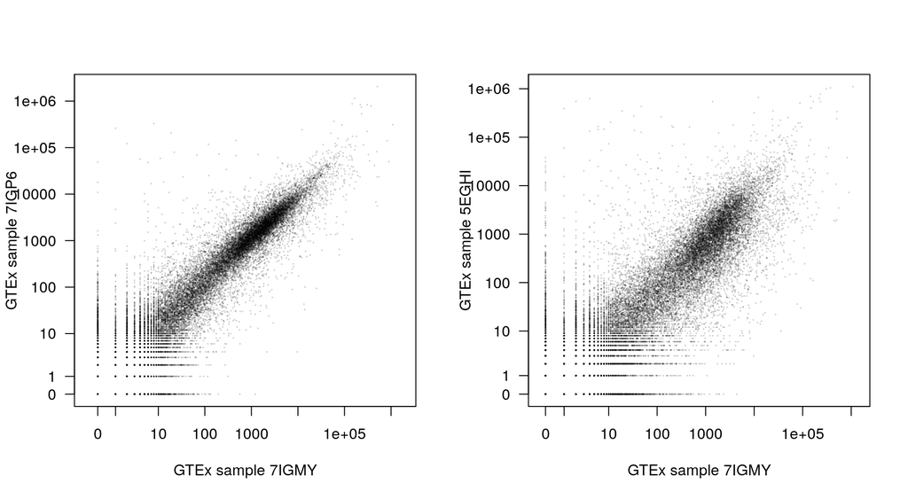

(Den Code zum Plotten habe ich hier ausgeblendet.)

Wie können wir die Ähnlichkeit von Proben quantifizieren?

Distanz- und Ähnlichkeitsmaße:

- Pearsons Korrelationskoeffizient
- Spearmans Korrelationskoeffzient
- Euklidsche Distanz der Expressionsvektoren
- Manhatten-Distanz der Expressionsvektoren
- Standardabweichung der Differenzen (der “log fold changes”)
- usw.

Wir besprechen zunächste die Pearson-Korrelation:

Wir möchten diese drei Spalten (“Vektoren”) vergleichen

```r
countMatrix[ , c( "7IGMY", "7IGP6", "5EGHI" ) ] %>% head( 20 )
```

```
##                   7IGMY 7IGP6 5EGHI
## DDX11L1               0     0     0
## WASH7P              111    95   109
## MIR6859-1             0     0     0
## MIR1302-2HG           0     0     0
## FAM138A               0     0     0
## OR4G4P                0     0     1
## OR4G11P               1     0     1
## OR4F5                 0     1     2
## RP11-34P13.7          6     1     2
## CICP27                2     0     1
## RP11-34P13.15        40    86     4
## RP11-34P13.16        21    38     3
## RP11-34P13.14         0     0     0
## RP11-34P13.13         5    39     4
## RNU6-1100P            0     0     0
## RP11-34P13.9          0     0     0
## ABC7-43046700E7.1     0     4     2
## RP11-34P13.18       125   101   136
## MIR6859-2             0     0     0
## AP006222.2           31    10    16
```

### Pearson-Korrelation

Die Korrelation der ersten mit der zweiten und mit der dritten Spalte:

```r
cor( countMatrix[,"7IGMY"], countMatrix[,"7IGP6"] )
```

```
## [1] 0.4689013
```

```r
cor( countMatrix[,"7IGMY"], countMatrix[,"5EGHI"] )
```

```
## [1] 0.4370337
```

Was wird hier berechnet?

Dasselbe in Einzelschritten:

1. Zur Vorbereitung berechnen wir die Mittelwerte der Vektoren:

$$\overline x = \frac{1}{n}\sum_{j=1}^n x_j \qquad\text{und}\qquad \overline y = \frac{1}{n}\sum_{j=1}^n y_j$$

2. Dann “zentrieren” wir die Daten, indem wir die Mittelwerte abziehen

$$\tilde x_j = x_j - \overline x,\qquad \text{und}\qquad \tilde y_j = y_j - \overline y.$$
3. Die zentrierten Daten haben jetzt die Mittelwerte 0. Nun berechnen wir die Summe der Produkte der Wertepaare:

$$\text{Produktsumme} = \sum_{j=1}^n \tilde x_j \tilde y_j$$

Beachte, wie die Summe davon abhängt, ob die Wertepaare, die wir multiplizieren, dasselbe Vorzeichen haben oder nicht.

Wenn wir die Produktsumme durch $n$ teilen, erhalten wir den Mittelwert der Produkte, genannt die Kovarianz.

Eine hohe Kovarianz bedeutet dass ein Gen meistens in beiden Proben hoch oder in beiden Proben niedrig ist, so dass das Produkt oft positiv ist.

Wann ist eine Kovarianz hoch?

Wenn $x$ und $y$ gleich sind, sind sie perfekt korreliert. Dann ist die Produktsumme $\sum_j \tilde x_j^2=\sum_j \tilde y_j^2$. Es scheint Sinn zu machen, den geometrischen Mittelwert dieser beiden Werte als Vergleichs-Maßstab zu nehmen, um zu sehen, ob die Kovarianz hoch ist:

WIr vergleichen $\sum_{j=1}^n \tilde x_j \tilde y_j$ mit $\sum_{j=1}^n \tilde x_j^2$ und $\sum_{j=1}^n \tilde y_j^2$, wie folgt:

$$\text{Pearsons Korrelationskoeffizient} = \frac{ \sum_{j=1}^n \tilde x_j \tilde y_j }{\sqrt{ \left(\sum_{j=1}^n \tilde x_j^2\right) \left(\sum_{j=1}^n \tilde y_j^2\right) }}$$
Dieser Wert ist stes zwischen -1 und 1.

Beachte aber: “Anscombe’s Quartett” – Diese vier Beispiele haben alle den gleichen Korrelationskoeffizienten:

[figure not shown]

(Bild: Wikipedia)

Zurück zu unseren Daten:

```r
cor( countMatrix[,"7IGMY"], countMatrix[,"7IGP6"] )
```

```
## [1] 0.4689013
```

Wir berechnen das nun in Einzelschritten:

Was sind die Mittelwerte $\overline x$ und $\overline y$?

```r
mean( countMatrix[,"7IGMY"] )
```

```
## [1] 1025.848
```

```r
mean( countMatrix[,"7IGP6"] )
```

```
## [1] 975.1269
```

Wir zeichnen die Mittelwerte ein:

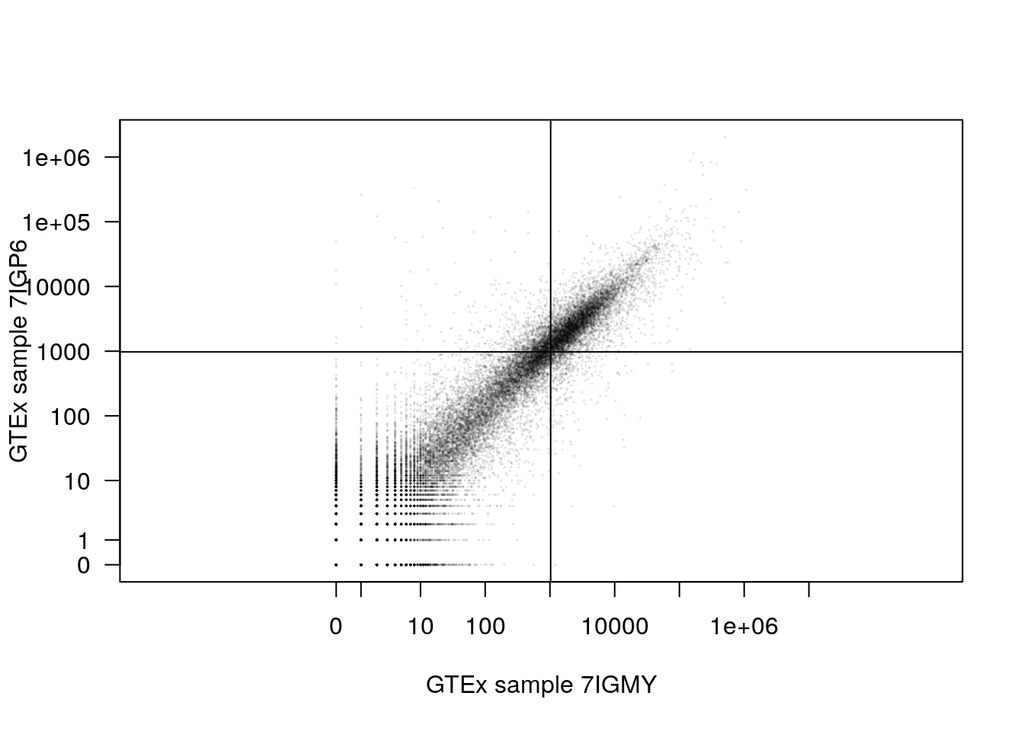

Nun zentrieren wir die Werte und berechnen die Produkte und Quadrate

```r
tibble(
  gene = rownames(countMatrix),
  x = countMatrix[,"7IGMY"],
  y = countMatrix[,"7IGP6"] ) %>%
mutate(
  x_centered = x - mean(x),
  y_centered = y - mean(y) ) %>%
mutate(
  product = x_centered * y_centered,
  x_centered_squared = x_centered^2,
  y_centered_squared = y_centered^2 )
```

```
## # A tibble: 56,200 x 8
##    gene      x     y x_centered y_centered product x_centered_squa…
##    <chr> <dbl> <dbl>      <dbl>      <dbl>   <dbl>            <dbl>
##  1 DDX1…     0     0     -1026.      -975.  1.00e6         1052364.
##  2 WASH…   111    95      -915.      -880.  8.05e5          836947.
##  3 MIR6…     0     0     -1026.      -975.  1.00e6         1052364.
##  4 MIR1…     0     0     -1026.      -975.  1.00e6         1052364.
##  5 FAM1…     0     0     -1026.      -975.  1.00e6         1052364.
##  6 OR4G…     0     0     -1026.      -975.  1.00e6         1052364.
##  7 OR4G…     1     0     -1025.      -975.  9.99e5         1050313.
##  8 OR4F5     0     1     -1026.      -974.  9.99e5         1052364.
##  9 RP11…     6     1     -1020.      -974.  9.93e5         1040090.
## 10 CICP…     2     0     -1024.      -975.  9.98e5         1048265.
## # … with 56,190 more rows, and 1 more variable: y_centered_squared <dbl>
```

Wir beenden die Rechnung, indem wir die Summen in der Formel bilden und die Division durchführen

```r
tibble(
  gene = rownames(countMatrix),
  x = countMatrix[,"7IGMY"],
  y = countMatrix[,"7IGP6"] ) %>%
mutate(
  x_centered = x - mean(x),
  y_centered = y - mean(y) ) %>%
mutate(
  product = x_centered * y_centered,
  x_centered_squared = x_centered^2,
  y_centered_squared = y_centered^2 ) %>%    # <- bis hier genauso wie oben
summarise(
  corrcoef = sum(product) /
    sqrt( sum(x_centered_squared) * sum(y_centered_squared) )
)
```

```
## # A tibble: 1 x 1
##   corrcoef
##      <dbl>
## 1    0.469
```

Wir betrachten nochmmal die einzelnen Summanden, und sortieren nach dem Produkt:

```r
tibble(
  gene = rownames(countMatrix),
  x = countMatrix[,"7IGMY"],
  y = countMatrix[,"7IGP6"] ) %>%
mutate(
  x_centered = x - mean(x),
  y_centered = y - mean(y) ) %>%
mutate(
  product = x_centered * y_centered,
  x_centered_squared = x_centered^2,
  y_centered_squared = y_centered^2 ) %>%
  arrange( desc(product) )
```

```
## # A tibble: 56,200 x 8
##    gene       x      y x_centered y_centered product x_centered_squa…
##    <chr>  <dbl>  <dbl>      <dbl>      <dbl>   <dbl>            <dbl>
##  1 MT-R… 5.09e5 2.04e6    507550.   2039758. 1.04e12    257607156860.
##  2 MT-C… 1.08e6 3.11e5   1078075.    309745. 3.34e11   1162246033498.
##  3 MT-C… 3.72e5 7.88e5    371305.    787152. 2.92e11    137867515949.
##  4 MT-N… 3.07e5 8.37e5    306347.    835562. 2.56e11     93848577578.
##  5 MT-N… 1.65e5 1.15e6    164468.   1148975. 1.89e11     27049773043.
##  6 MT-C… 2.20e5 8.31e5    218487.    829898. 1.81e11     47736635617.
##  7 MT-C… 2.31e5 7.36e5    230296.    735053. 1.69e11     53036317656.
##  8 MT-A… 1.46e5 8.74e5    145429.    872761. 1.27e11     21149638270.
##  9 MT-N… 2.32e5 5.31e5    231164.    529532. 1.22e11     53436865199.
## 10 ACTB  8.31e5 1.41e5    829490.    139739. 1.16e11    688053912371.
## # … with 56,190 more rows, and 1 more variable: y_centered_squared <dbl>
```

Was geschieht, wenn wir nur die Zeilen mit den 100 höchsten Werten verwenden?

```r
tibble(
  gene = rownames(countMatrix),
  x = countMatrix[,"7IGMY"],
  y = countMatrix[,"7IGP6"] ) %>%
mutate(
  x_centered = x - mean(x),
  y_centered = y - mean(y) ) %>%
mutate(
  product = x_centered * y_centered,
  x_centered_squared = x_centered^2,
  y_centered_squared = y_centered^2 ) %>%   # <-- bis hier wie zuvor
arrange( desc(product) )  %>%               # <-- sortiere nach Produkt-Wert
head( 100 ) %>%                             # <-- verwende nur die 100 ersten (höchsten) Werte
summarise(                                  # <-- und weiter wie bisher
  corrcoef = sum(product) /
    sqrt( sum(x_centered_squared) * sum(y_centered_squared) )
)
```

```
## # A tibble: 1 x 1
##   corrcoef
##      <dbl>
## 1    0.464
```

Wir erhalten fast genau deselben Wert wie zuvor! Der Wert wird also fast nur von den höchst-exprimierten Genen bestimmt. Der Großteil unserer Daten hat kaum Einfluß auf das Ergebnis. Das ist nicht gut.

Das Problem hier ist “Heteroskedastizität”: bei stark exprimierten Genen sind nicht nur die absoluten Werte groß, sondern auch die Differenzen zwischen den Proben. Dies erkennt man gut wie folgt:

Wir berechnen Mittelwert und Standardabweichung für alle Gene in unserer Datenmatrix und plotten dies

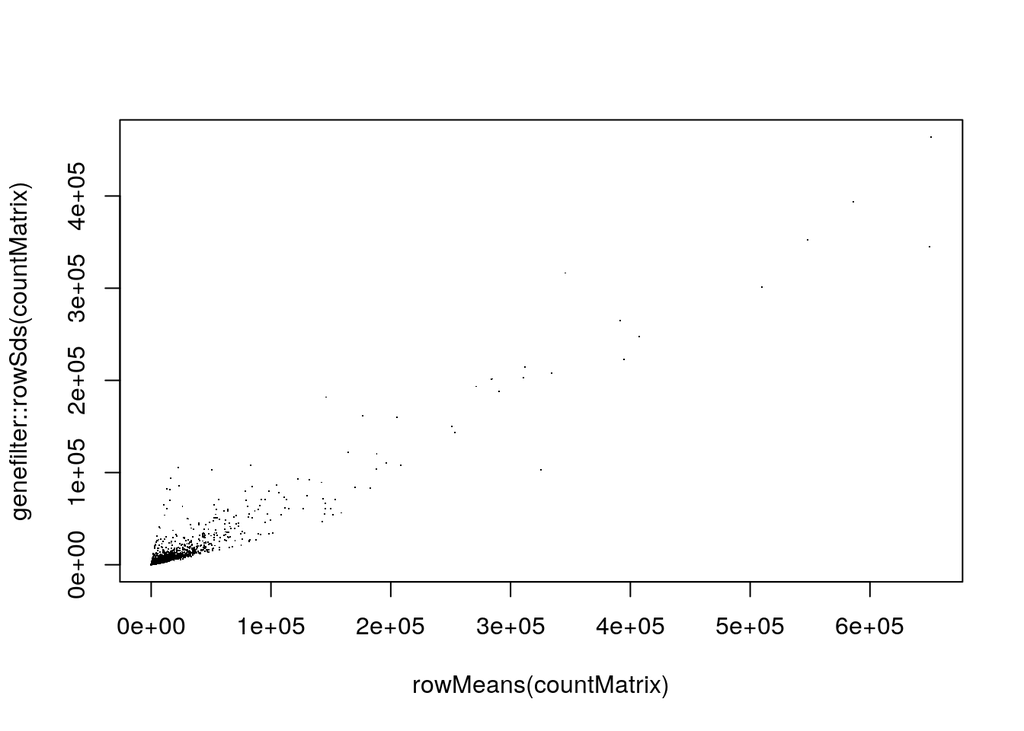

```r
plot(
  x = rowMeans( countMatrix ),
  y = genefilter::rowSds( countMatrix ),
  pch = "." )
```

(Hier habe ich Base-R-Plotting statt ggplot verwendet.)

Dasselbe nochmal, mit logarithmischen Achsen

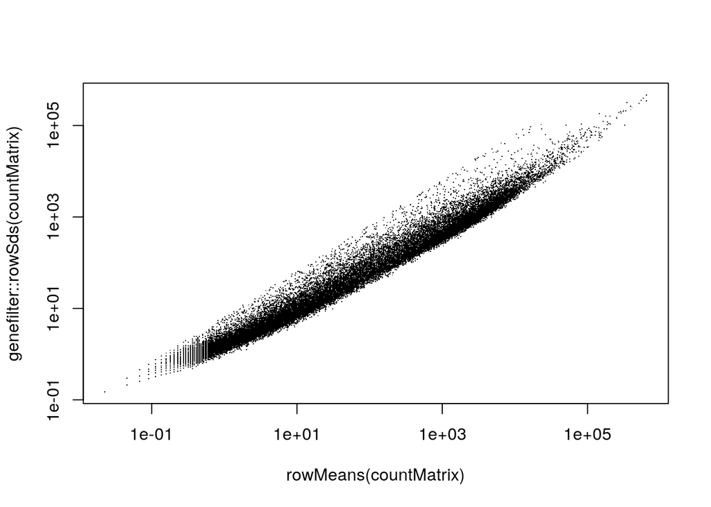

```r
plot(
  x = rowMeans( countMatrix ),
  y = genefilter::rowSds( countMatrix ),
  pch = ".", log="xy" )
```

Die Standardabweichung variert über 6 Größenordnungen: Die Gene rechts oben haben fast eine Million so viel Einfluß auf den Korrelationskoeffizienten wie die Gene links unten

Vielleich hilft es, den Logarithmus zu nehmen? Wir verwenden hier “log1p”:

$$\mathtt{log1p}(x) = \ln( 1 + x )$$

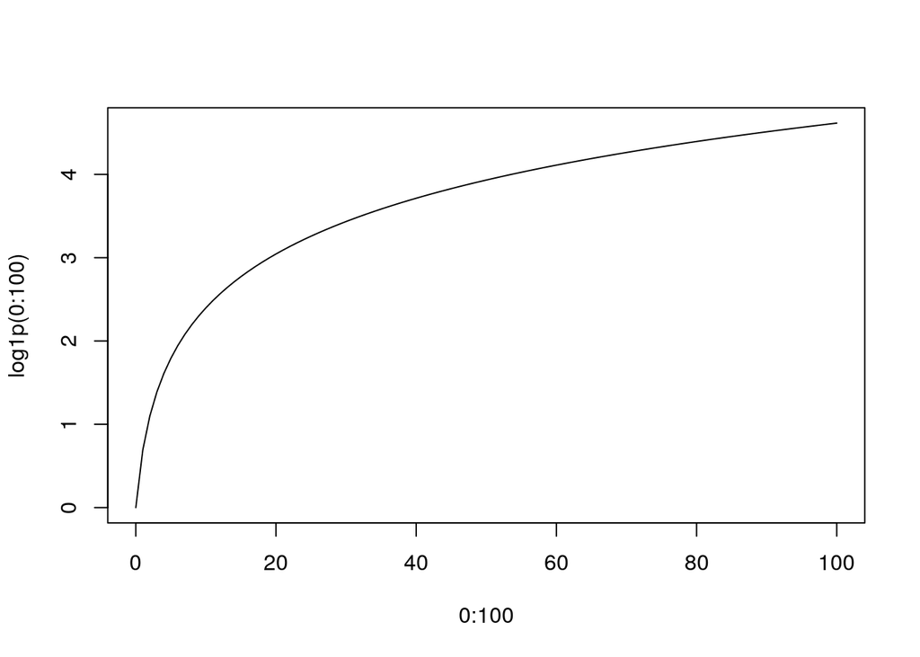

Wir nehmen erst den Logarithmus, dann berechnen wir Mittelwert und Standardabweichung

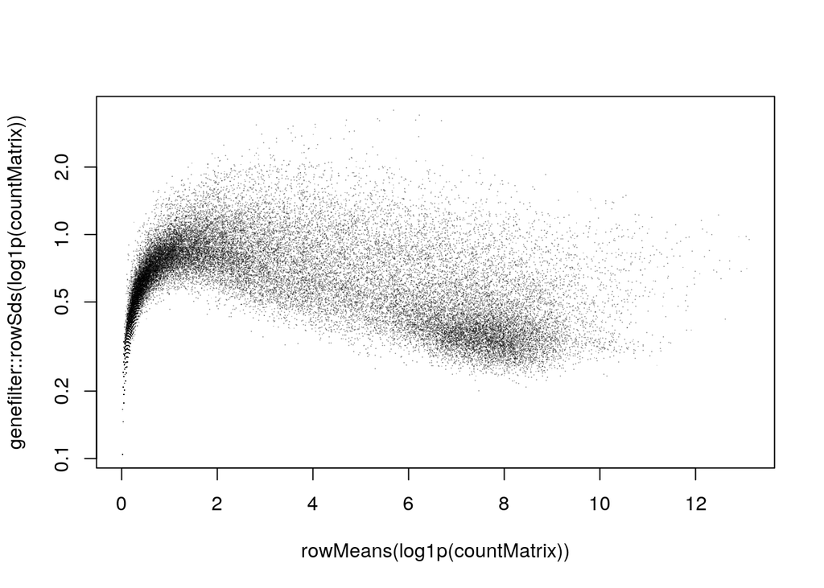

```r
plot(
  x = rowMeans( log1p(countMatrix) ),
  y = genefilter::rowSds( log1p(countMatrix) ),
  pch = ".", log="y", col=adjustcolor("black",.3) )
```

Viel besser: Jetzt variiert die Standardabweichung nur noch über eine Größenordnung.

So eine Transformation nennt man eine “varianz-stabilisierende Transformation”. Sie hilft, sicherzustellen, dass alle Gene inigermaßen gleichermaßen Einfluß auf Ergebnisse haben.

Wir berechnen nochmal die beiden Korrelationskoeffzienten von oben, nun aber nachdem wir die Daten log-transformiert haben:

```r
cor( log1p( countMatrix[,"7IGMY"] ), log1p( countMatrix[,"7IGP6"] ) )
```

```
## [1] 0.9613769
```

```r
cor( log1p( countMatrix[,"7IGMY"] ), log1p( countMatrix[,"5EGHI"] ) )
```

```
## [1] 0.9238473
```

Wir können auch die Korrelationskoeffizienten für alle Paare von allen Proben so berechnen: Wenn man der `cor`-Funktion eine Matrix gibt, berechnet sie den Korrelationskoeffizienten jeder Spalte gegen jede andere Spalte.

```r
cor( log1p( countMatrix ) ) -> corrMatrix

corrMatrix[ 1:8, 1:8 ]
```

```
##           5EGHI     5GZZP     5EQKS     59HJ5     5LZU2     5EQ5I     5K7UU
## 5EGHI 1.0000000 0.9274534 0.9225431 0.9237467 0.9272619 0.9164247 0.9216671
## 5GZZP 0.9274534 1.0000000 0.9669677 0.9671611 0.9719614 0.9690155 0.9763403
## 5EQKS 0.9225431 0.9669677 1.0000000 0.9699265 0.9664984 0.9726870 0.9726447
## 59HJ5 0.9237467 0.9671611 0.9699265 1.0000000 0.9776341 0.9666085 0.9685040
## 5LZU2 0.9272619 0.9719614 0.9664984 0.9776341 1.0000000 0.9646493 0.9715680
## 5EQ5I 0.9164247 0.9690155 0.9726870 0.9666085 0.9646493 1.0000000 0.9746543
## 5K7UU 0.9216671 0.9763403 0.9726447 0.9685040 0.9715680 0.9746543 1.0000000
## 5IJBT 0.9205438 0.9766619 0.9720161 0.9683753 0.9713960 0.9764992 0.9811823
##           5IJBT
## 5EGHI 0.9205438
## 5GZZP 0.9766619
## 5EQKS 0.9720161
## 59HJ5 0.9683753
## 5LZU2 0.9713960
## 5EQ5I 0.9764992
## 5K7UU 0.9811823
## 5IJBT 1.0000000
```

Anstatt die Zahlen anzusehen, ist es hilfreich, die Matrix als “Heatmap” zu visualisieren:

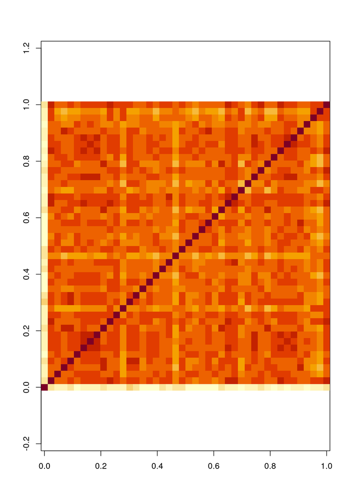

```r
image( corrMatrix, asp=1 )
```

Der folgende, etwas kompliziertere, Befehl kann das etwas schöner:

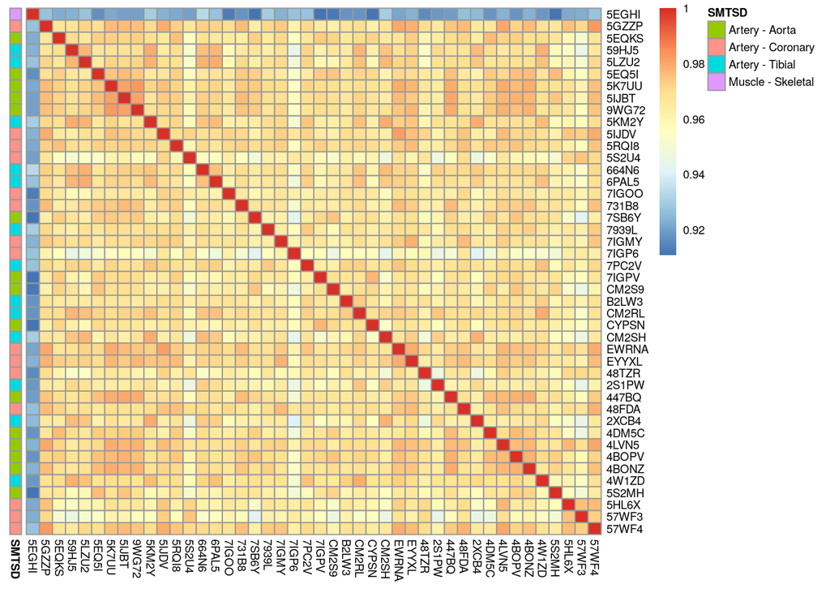

```r
sampleTable %>% column_to_rownames( "sample_id" ) %>%
  as.data.frame %>% `[`( , "SMTSD", drop=FALSE ) -> a

pheatmap::pheatmap(
  corrMatrix,
  cluster_rows=FALSE, cluster_cols=FALSE,
  annotation_row = a, fontsize=7 )
```

So eine Heatmap wird übersichtlicher, wenn man die Proben geeignet sortiert, z.B. so dass Proben vom selben Gewebe (Spalte “SMTSD” in der Proben-Tabelle) nebeneinander liegen:

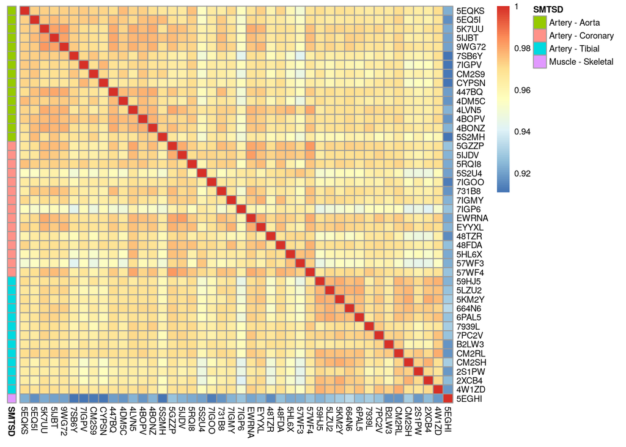

```r
o <- order( sampleTable$SMTSD )

pheatmap::pheatmap(
  corrMatrix[o,o],
  cluster_rows=FALSE, cluster_cols=FALSE,
  annotation_row = a[o,,drop=FALSE], fontsize=7 )
```

Es hilft, mit verschiedenen Farbskalen zu experimentieren. Die Viridis-Skalen sind darauf optimiert, optisch gleichmäßige Farbverläufe zu erreichen:

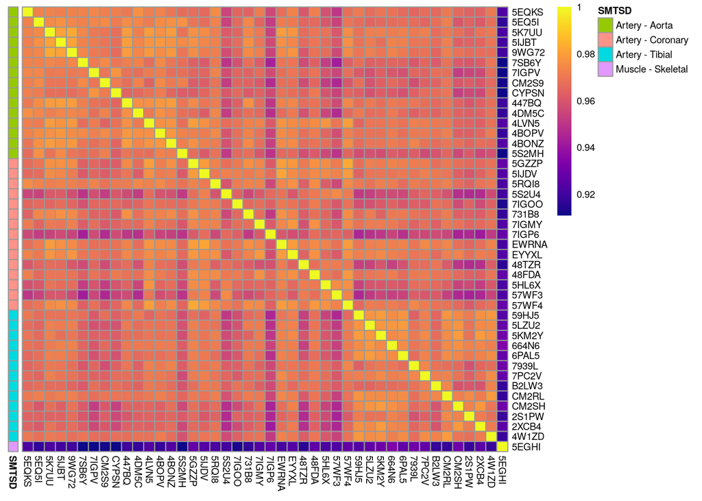

```r
o <- order( sampleTable$SMTSD )

pheatmap::pheatmap(
  corrMatrix[o,o],
  cluster_rows=FALSE, cluster_cols=FALSE,
  annotation_row = a[o,,drop=FALSE], fontsize=7,
  color = viridis::plasma(100) )
```

Anstatt die Proben-Annotation zu verwenden, um die Proben anzuordnen, kann man auch Proben nebeneinander setzten lassen, die stark korreliert sind. Die “hclust”-Funktion findet so eine Anordnung:

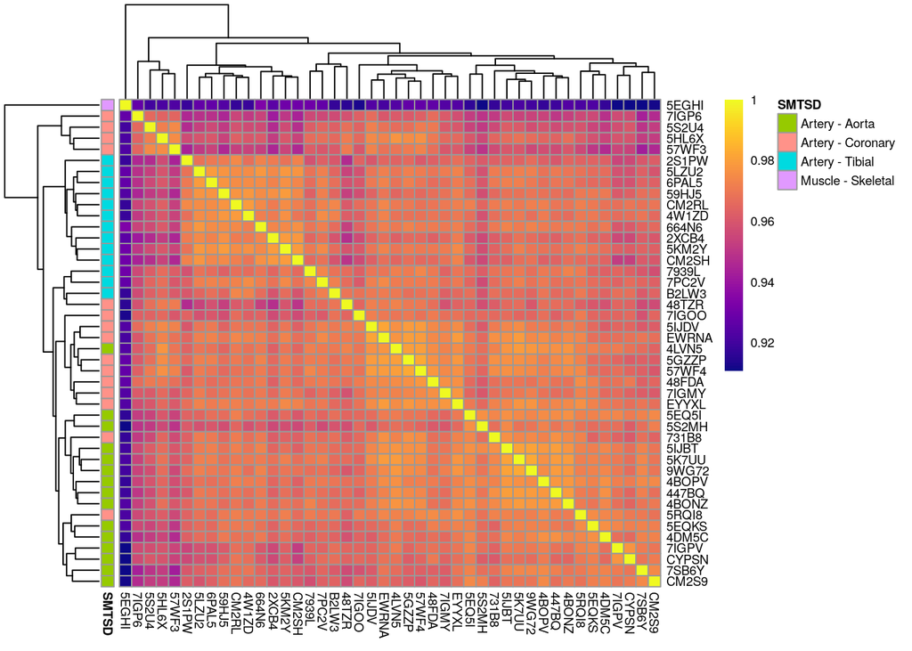

```r
cl = hclust( as.dist( 1-corrMatrix ) )

pheatmap::pheatmap(
  corrMatrix,
  cluster_rows=cl, cluster_cols=cl,
  annotation_row = a, fontsize=7,
  color = viridis::plasma(100) )
```

Die Linien am Rand sind sogenannte “Dendrogramme” (oder: Cluster-Bäume)

Wie wurden sie erstellt?

## Hierarchisches Clustering

(auch genannt: agglomoratives Clustering)

Gegeben: Objekte (hier: Proben) und eine Distanzmatrix (hier: Korrelationskoeffizienten zwischen Proben)

Initialisierung: Jedes Objekt bildet einen “Cluster”

Wiederhole folgendes, bis alle Objekte in einem großen CLuster liegen:

- Finde die zwei ähnlichsten Cluster und fasse Sie zu einem größeren Cluster zusammen.

Das Dendrogramm beschreibt, wie die Objekte zu Clustern zusammengefasst wurden.

Die Länge der “Äste” gibt den Abstand der vereinigten Cluster wieder:

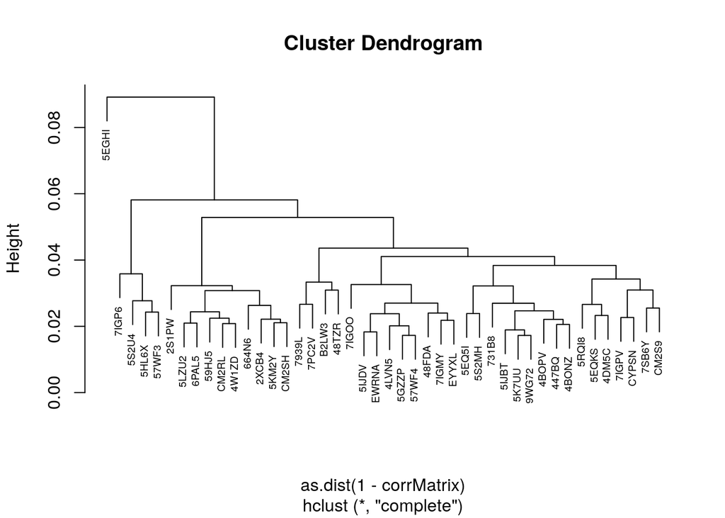

```r
plot( hclust( as.dist( 1-corrMatrix ), method="complete" ), cex=.6 )
```

Wie bestimmt man die Ähnlichkeit zweier CLuster?

- Wenn beide Cluster einzelne Objekte sind, schaut man in die Distanz-Matrix (hier: Distanz = 1 - Korrelation)
- Wenn die CLuster jeweils mehrere Objekte enthalten, gibt es verschiedene Möglichkeiten. Man betrachtet die Abstände jedes Objekts im ersten CLuster zu jedem Objekt im zweiten Cluster uns nimmt
- den kleinsten Wert (“single linkage”)
- den größten Wert (“complete linkage”) – hier verwendet
- den Mittelwert (“average linkage”) oder man berechnet, wann immer man zwei Cluster vereinigt, einen neuen Expressions-Vektor, indem man für jedes Gen den Mittelwert der transformierten Werte berechnet. Auch hier gibt es mehrere Möglichkeiten.

## Medians

Dat GTex-Projekt bietet eine Matrix an mit den Median-Expressionswerten für jedes Gewebe. Hier ist die Matrix `GTEx_Analysis_2017-06-05_v8_RNASeQCv1.1.9_gene_median_tpm.gct.gz`, schon leicht vorbereitet:

```r
dim( tissueMedians )
```

```
## [1] 56200    54
```

```r
tissueMedians[1:5,1:5]
```

```
##             Adipose - Subcutaneous Adipose - Visceral (Omentum) Adrenal Gland
## DDX11L1                    0.00000                      0.00000       0.00000
## WASH7P                     4.06403                      3.37111       2.68549
## MIR6859-1                  0.00000                      0.00000       0.00000
## MIR1302-2HG                0.00000                      0.00000       0.00000
## FAM138A                    0.00000                      0.00000       0.00000
##             Artery - Aorta Artery - Coronary
## DDX11L1            0.00000           0.00000
## WASH7P             4.04762           3.90076
## MIR6859-1          0.00000           0.00000
## MIR1302-2HG        0.00000           0.00000
## FAM138A            0.00000           0.00000
```

Auch hier können wir die Korrelation zwischen jedem Paar an Geweben errechen, und dies als Input zum hierarchischen CLustern verwenden:

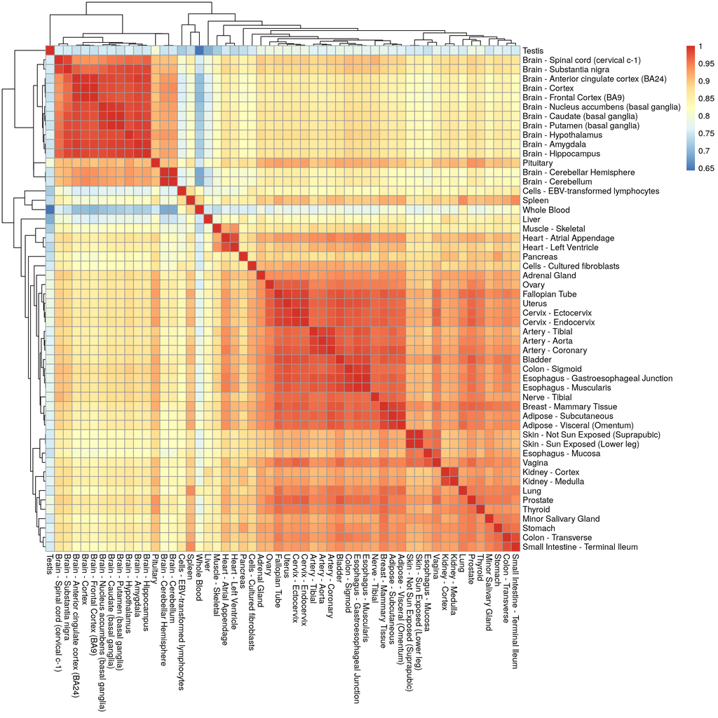

```r
cor( log1p( tissueMedians ) ) -> tissueCorrMatrix

tcl <- hclust( as.dist( 1-tissueCorrMatrix ) )
pheatmap::pheatmap( tissueCorrMatrix, cluster_rows=tcl, cluster_cols=tcl  )
```